# Microbiome Data Analysis and Figure Generation

The first step is to load the necessary packages. pacman will install and load any missing packages.

```r
if (!require("pacman")) install.packages("pacman")
pacman::p_load(decontam, phyloseq, BiocManager, qiime2R, DESeq2, tidyverse, RColorBrewer, viridis, vegan,  ggplot2, patchwork, ggpubr, ranacapa, nlme, compositions, readr, devtools, microViz, ANCOMBC, microbiome, GUniFrac, scales, DT, microshades, dplyr, cowplot)
```

Use the Qiime2R plugin to import .qza files into a phyloseq object “phy”. Import the rarefied table from Qiime2 that was used to calculate the statistics.

```r
phy = qza_to_phyloseq("core-metrics-results/rarefied_table.qza", "rooted-tree.qza", "taxonomy.qza", "metadata.txt",tmp = "C:/tmp")
```

Verfiy that all samples have an even read depth.

```r
sample_sums(phy)
```

```
             A1_10024_I              A1_10029_I              A1_10049_I              A1_10050_I
                   3746                    3746                    3746                    3746
             A2_10072_I              A3_10048_I            A2_10113_A_I              A3_10012_I
                   3746                    3746                    3746                    3746
             A3_10014_I              A3_10017_I              A1_10068_I              A2_10056_I
                   3746                    3746                    3746                    3746
             A2_10067_I              A3_10022_I              210040142_              210040181_
                   3746                    3746                    3746                    3746
             210040183_              210040184_              210040191_              210040192_
                   3746                    3746                    3746                    3746
             210040150_              210040152_              210040159_              210040160_
                   3746                    3746                    3746                    3746
             210040163_              210040166_              210040169_              210040171_
                   3746                    3746                    3746                    3746
             210040177_              210040196_           R3_2100430005          R3_2100430007A
                   3746                    3746                    3746                    3746
          R3_2100430012           R3_2100430015          R3_2100430018A           R3_2100430024
                   3746                    3746                    3746                    3746
          R3_2100430032          R3_2100430034A           R3_2100440006           R3_2100440020
                   3746                    3746                    3746                    3746
          R3_2100440026           R3_2100440031           R3_2100440037           R3_2100440051
                   3746                    3746                    3746                    3746
          R3_2100440064          R3_2100440087B           R3_2100450011 R3_2100450012_replicate
                   3746                    3746                    3746                    3746
          R3_2100450015           R3_2100450016          R3_2100450019A           R3_2100450021
                   3746                    3746                    3746                    3746
          R3_2100450023           R3_2100450024           R3_2100450026           R3_2100450027
                   3746                    3746                    3746                    3746
          R3_2100450029           R3_2100450030           R3_2100450034           R3_2100450037
                   3746                    3746                    3746                    3746
```

Ordinations

First, create a phyloseq object that is collapsed to the species level for Jaccard and Bray-Curtis. This is to prevent an artifact from a batching effect from the ASV-calling step.

```r
phy_spe = tax_glom(phy, taxrank = "Species")
```

Set the colors for to NMDS plots. The first is for Colombia, the second is for the US.

```r
hex_values <- c("#FFCD00", "#396998")
```

Create the NMDS plots for all four beta diversity distance measures.

```r
phy_jac = ordinate(
  phy_spe, method = "NMDS", distance = "jaccard", binary="TRUE", trymax = 100
  )
```

```
Square root transformation
Wisconsin double standardization
*** No convergence -- monoMDS stopping criteria:
    24: no. of iterations >= maxit
    76: stress ratio > sratmax
```

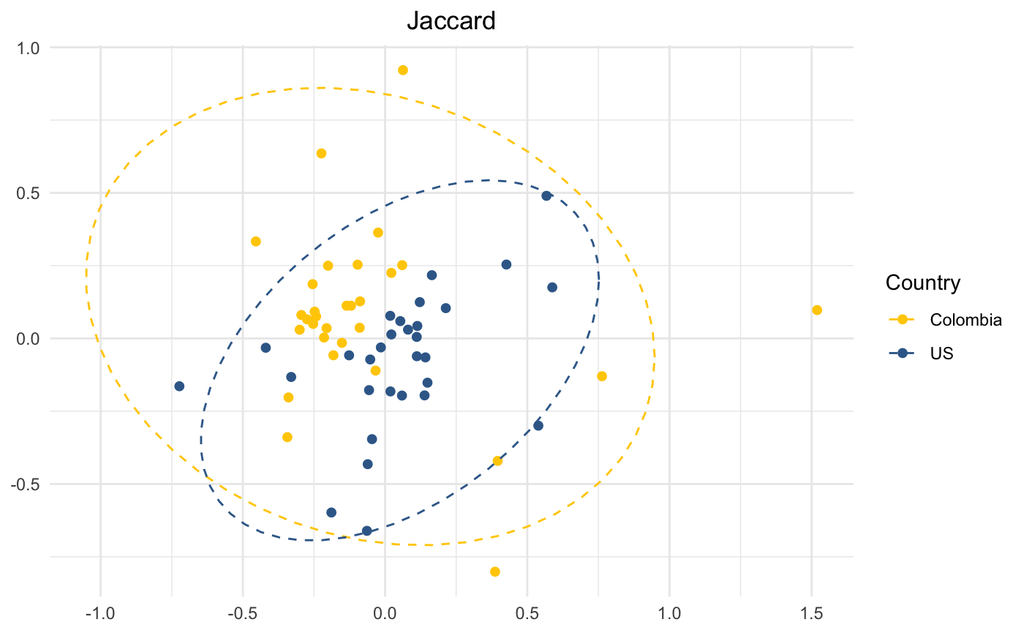

```r
p1 = plot_ordination(
  phy_spe, phy_jac, color = "Country"
  )
f1a <- p1 +
  geom_point(size=1.75) +
  ggtitle("Jaccard") +
  stat_ellipse(mapping = aes(x=NMDS1, y=NMDS2, group=Country),
               type = "norm", linetype = 2) +
  theme_bw() +
  theme(axis.title = element_blank(), panel.border = element_blank(), axis.ticks = element_blank(), plot.title = element_text(hjust = 0.5)) +
  scale_color_manual(values = hex_values, na.translate = FALSE)
f1a
```

```r
phy_bray = ordinate(
  phy_spe, method = "NMDS", distance = "bray", trymax = 100
  )
```

```
Square root transformation
Wisconsin double standardization
*** Solution reached
```

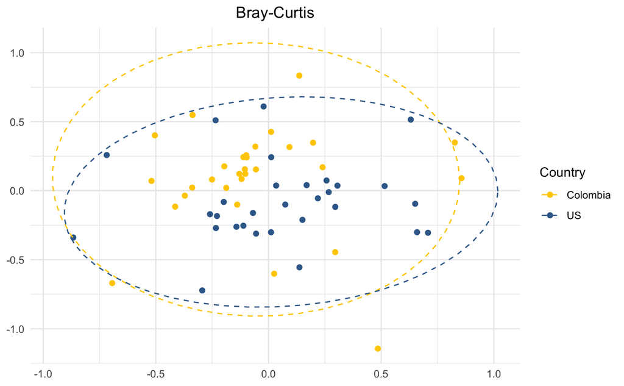

```r
p2 = plot_ordination(
  phy_spe, phy_bray, color = "Country"
  )
f1b <- p2 +
  geom_point(size=1.75) +
  ggtitle("Bray-Curtis") +
  stat_ellipse(mapping = aes(x=NMDS1, y=NMDS2, group=Country),
               type = "norm", linetype = 2) +
  theme_bw() +
  theme(axis.title = element_blank(), panel.border = element_blank(), axis.ticks = element_blank(), plot.title = element_text(hjust = 0.5)) +
  scale_color_manual(values = hex_values, na.translate = FALSE)
f1b
```

```r
phy_ununi = ordinate(
  phy, method = "NMDS", distance = "uunifrac"
  )
```

```
*** No convergence -- monoMDS stopping criteria:
    20: stress ratio > sratmax
```

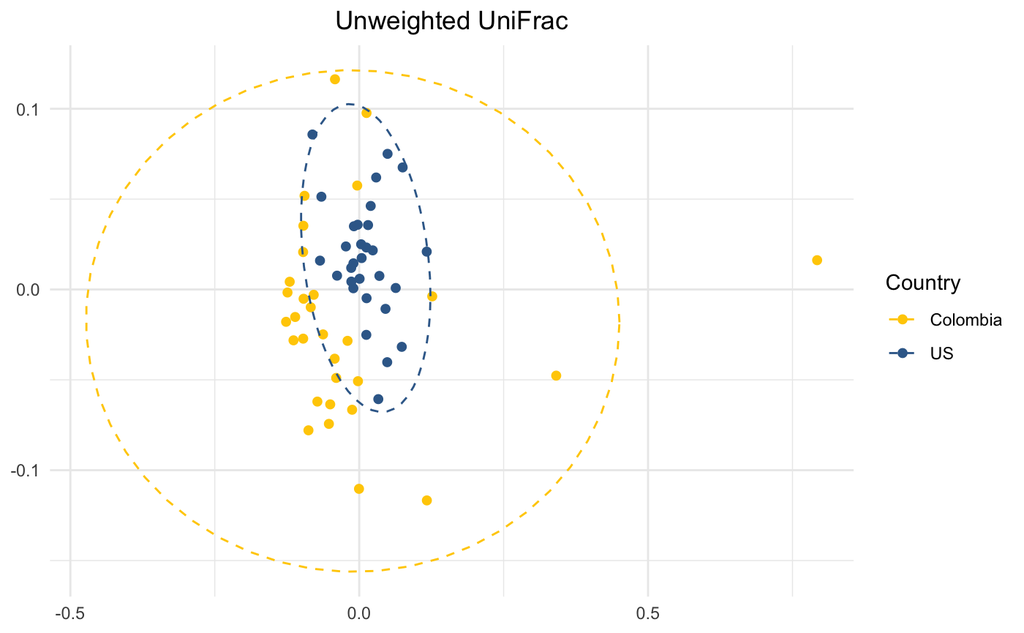

```r
p3 = plot_ordination(
  phy, phy_ununi, color = "Country"
  )
f1c <- p3 +
  geom_point(size=1.75) +
  ggtitle("Unweighted UniFrac") +
  stat_ellipse(mapping = aes(x=NMDS1, y=NMDS2, group=Country),
               type = "norm", linetype = 2) +
  theme_bw() +
  theme(axis.title = element_blank(), panel.border = element_blank(), axis.ticks = element_blank(), plot.title = element_text(hjust = 0.5)) +
  scale_color_manual(values = hex_values, na.translate = FALSE)
f1c
```

```r
phy_wuni = ordinate(
  phy, method = "NMDS", distance = "wunifrac"
  )
```

```
*** No convergence -- monoMDS stopping criteria:
    18: stress ratio > sratmax
     2: scale factor of the gradient < sfgrmin
```

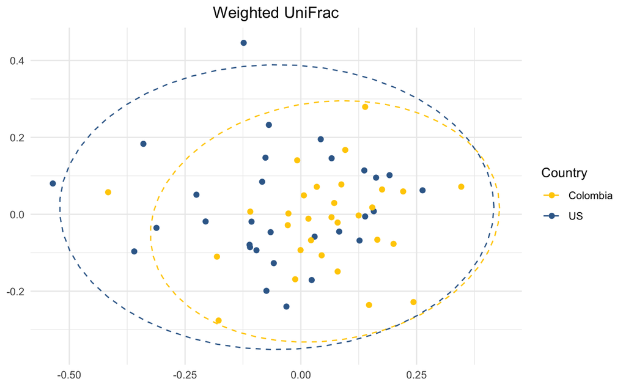

```r
p4 = plot_ordination(
    phy, phy_wuni, color = "Country"
  )
f1d <- p4 +
  geom_point(size=1.75) +
  ggtitle("Weighted UniFrac") +
  stat_ellipse(mapping = aes(x=NMDS1, y=NMDS2, group=Country),
               type = "norm", linetype = 2) +
  theme_bw() +
  theme(axis.title = element_blank(), panel.border = element_blank(), axis.ticks = element_blank(), plot.title = element_text(hjust = 0.5)) +
  scale_color_manual(values = hex_values, na.translate = FALSE)
f1d
```

Combine the four NMDS plots into a single figure, and create a shared legend and axis titles. Label them with D-G for the final figure. Export it as a .tiff file.

```r
#f1a + f1b + f1c + f1d

yleft <- text_grob("NMDS 2                                              NMDS 2  ", rot = 90)
bottom <- text_grob("NMDS 1                                                                              NMDS 1          ")


nmds <- { wrap_elements(yleft) +
    {{f1a + f1b + f1c + f1d}} +
    plot_layout(widths = c(1,20)) } /
  bottom +
  plot_layout(heights=c(100,1), guides = "collect") + plot_annotation(tag_levels = list(c(' ', 'D', 'E', 'F', 'G')))                     #optional labeling of individual plots
```

|  | t | l | b | r |
| --- | --- | --- | --- | --- |
| 1: | 1 | 1 | 1 | 1 |
| 2: | 1 | 2 | 1 | 2 |

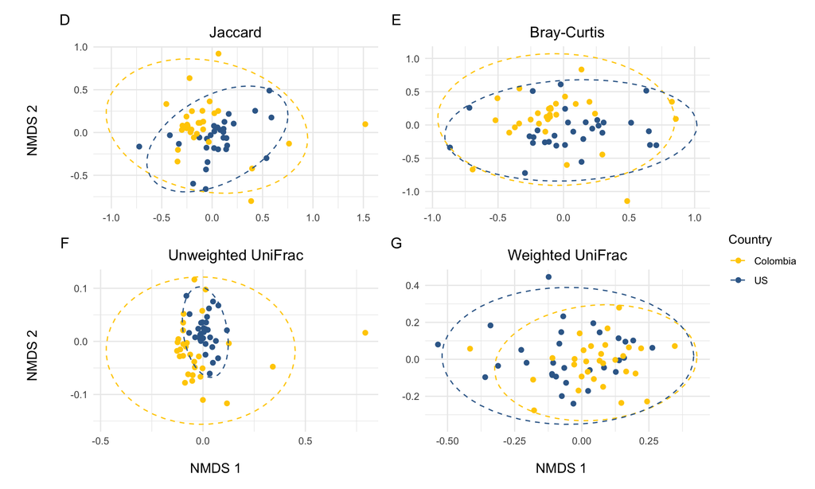

```r
nmds
```

```r
ggsave("ordinations.tiff")
```

Barplot

Now, we’re going to make a taxa barplot using MicroViz. The first step is to remove unknown labels. To find all of the unknown taxa, use the interactive taxa searcher.

```r
tax_fix_interactive(phy)
```

Edit your phyloseq object using the code from the interactive viewer, and save it as a new phyloseq object.

```r
phy1 <- phy %>%
 tax_fix(
  min_length = 4,
  unknowns = c("Unknown_genus", "Unknown_order", "Unknown_class", "Unknown_family", "Unknown_genus_unclassified", "Unknown_family_unclassified", "unclassified"),
  sep = " ", anon_unique = FALSE,
  suffix_rank = "current"
 )
```

[output not shown]

[output cut: 597 more lines]

[output not shown]

Set palettes for the barplots, using a single color for a phylum and different shades of the color as different genera within that phylum. We’ll look at the top 5 most abundant phyla, and the top three most abundant genera in each. All genera after those top three will be listed as “other”, so we need a fourth color to represent them. Additionally, all phyla not part of the 5 most abundant will be grouped within an “other” category, which we will represent with various shades of gray.

We will take colors from the microshades package. Start by creating vectors for each color with the shades. By default, microshades lists colors from lightest to darkest, so we will reverse the order using the rev() command. Finally, we’ll combine the lists of colors into a single list. Note that we only have 3 shades of orange. This is because our fourth most abundant phylum, Fusobacteria, only has 3 genera in our dataset, meaning an additional color is not necessary.

```r
#View the default microshades palettes with microshades_cvd_palettes and microshades_palettes

micro_gray <- c("#bdbdbd", "#969696", "#737373", "#525252")
micro_brown <- c("#CAA995", "#B78560", "#9E5C00", "#7D3200")
micro_green <- c("#a1d99b", "#74c476", "#41ab5d", "#238b45")
micro_orange <- c("#fdae6b","#fe9929", "#ff7f00")
micro_blue <- c("#c6dbef", "#9ecae1", "#6baed6", "#4292c6")
micro_purple <- c("#bcbddc", "#9e9ac8", "#807dba", "#6a51a3")

micro_gray <- rev(micro_gray)
micro_brown <- rev(micro_brown)
micro_green <- rev(micro_green)
micro_orange <- rev(micro_orange)
micro_blue <- rev(micro_blue)
micro_purple <- rev(micro_purple)

microcolors <- c(micro_blue, micro_purple, micro_green, micro_orange, micro_brown, micro_gray)
```

Assign the colors and shades to the appropriate taxa. Note that this command will generate an error message with our specific dataset because we have only 3 members of Fusobacteria. We can ignore it.

```r
hueRank <- "Phylum"
hueRankPlural <- "Phyla"
shadeRank <- "Genus"

# Sort phyloseq at lower, and then higher ranks
pseq2 <-phy1 %>%
  tax_sort(by = sum, at = shadeRank, tree_warn = FALSE) %>%
  tax_sort(by = sum, at = hueRank, tree_warn = FALSE) %>%
  tax_agg(rank = shadeRank)

# Specify number of hues and shades desired
nHues <- 5 # "Other" phyla will be shades of grey
nShades <- 4 # "Other" families will be the lightest shade of each hue

hierarchicalPalInfo <- data.frame(
  hue = as.vector(tt_get(pseq2)[, hueRank]),
  shade = as.vector(tt_get(pseq2)[, shadeRank]),
  counts = taxa_sums(otu_get(pseq2))
)

hierarchicalPalInfo <- hierarchicalPalInfo %>%
  dplyr::mutate(
    hue = forcats::fct_other(
      f = hue, keep = unique(hue)[seq_len(nHues)],
      other_level = paste("Other", hueRankPlural)
    ),
    nChrHue = nchar(as.character(hue)), padHue = max(nChrHue) - nChrHue
  ) %>%
  dplyr::group_by(hue) %>%
  dplyr::mutate(
    shade = forcats::fct_other(
      f = shade, keep = unique(shade)[seq_len(nShades - 1)],
      other_level = "Other"
    )
  ) %>%
  dplyr::ungroup() %>%
  dplyr::mutate(
    nChrShade = nchar(as.character(shade)), padShade = max(nChrShade) - nChrShade,
    Taxa = paste0(hue, ": ", strrep(" ", padHue), shade, strrep(" ", padShade))
  )
hierarchicalPalMatrix <- matrix(
  data = sapply(
    X = seq(from = 30, to = 75, length.out = nShades),
    FUN = function(l) scales::hue_pal(l = l, h.start = 30)(n = nHues)
  ),
  byrow = TRUE, ncol = nHues
)
hierarchicalPalMatrix <- cbind(hierarchicalPalMatrix, grey.colors(n = nShades))
hierarchicalPalMatrix <- microcolors

hierarchicalPal <- hierarchicalPalMatrix %>%
  as.vector() %>%
  setNames(unique(hierarchicalPalInfo$Taxa))
```

This is an optional command to generate a plot of each color and the associated phylum and genus. This same information is included with the figure legend of the barplot.

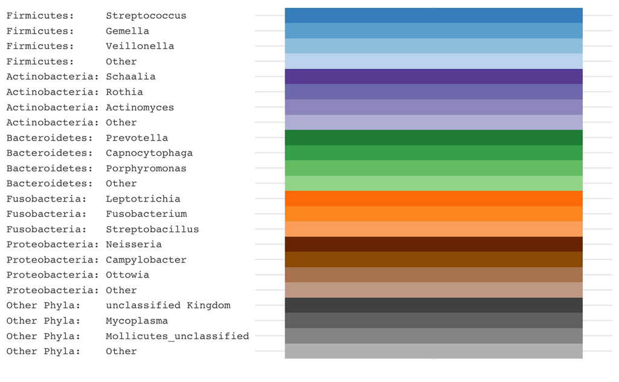

```r
tax_palette_plot(hierarchicalPal) +
  theme(axis.text.y.left = element_text(family = "mono"))
```

Generate the barplot and label it as H. Export it as a .tiff file.

```r
bars1 <- pseq2 %>%
  ps_get() %>%
  tax_mutate("Phylum: Genus" = hierarchicalPalInfo$Taxa, .keep = "none") %>%
  ps_mutate(
    Country = factor(
      Country, levels = c("US","Colombia"), ordered = TRUE)
  ) %>%
  comp_barplot(
    tax_level = "Phylum: Genus", n_taxa = length(hierarchicalPal),
    tax_order = "asis", palette = hierarchicalPal, bar_width = .85,
    label = "SubjectID"
  ) +
  facet_grid(
    rows = vars(Country),
    scales = "free", space = "free"
  ) +
  coord_flip() +
  guides(fill=guide_legend(ncol=1, reverse = FALSE, title="Phylum: Genus"))

barplot <- {{bars1}} +
  plot_annotation(tag_levels = list(c('H')))
```

|  | t | l | b | r |
| --- | --- | --- | --- | --- |
| 1: | 1 | 1 | 1 | 1 |

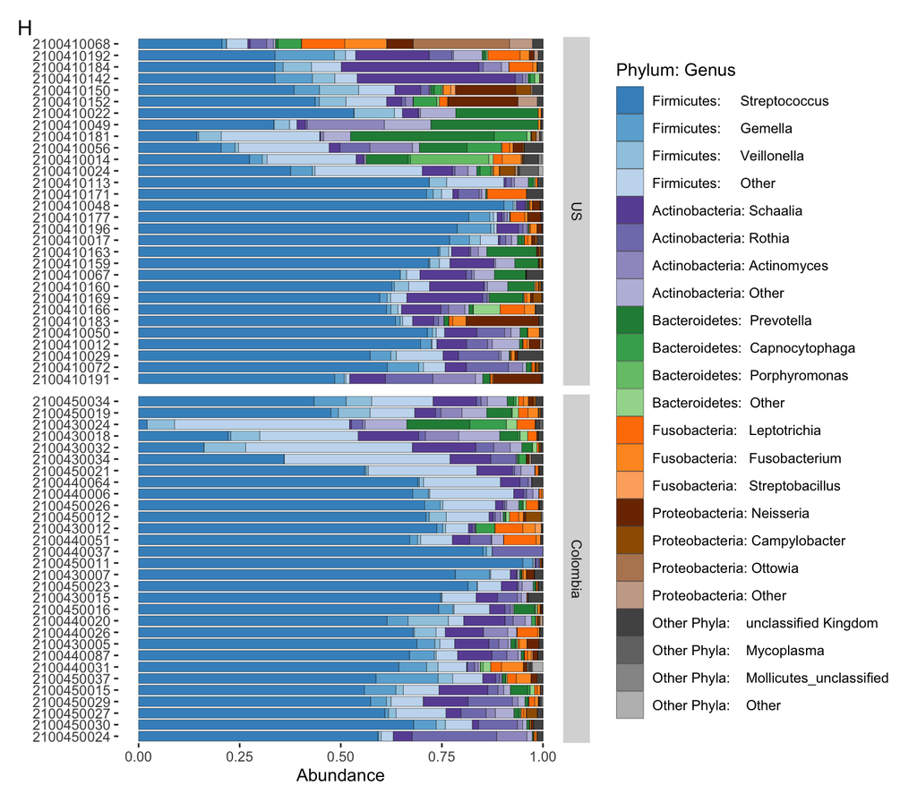

```r
barplot
```

```r
ggsave("barplot.tiff")
```

Boxplots

We already calculated alpha diversity with Qiime2. To download that data, view the appropriate .qzv file, and select the option “Download raw data as TSV”. Prepare the TSV file for import by removing the second row, which contains Qiime2-specific information. Also, label the p-value from the Qiime2 visualization and appropriate number of * to mark the significance on the plot.

Start with importing the Shannon diversity data.

```r
sh <- read_tsv("shannon.txt")
stat.test.sh <- tibble::tribble(
  ~group1,  ~group2,     ~p.adj,   ~p.adj.label,
    "US",  "Colombia",  0.000066,  "***"
  )
```

Create the boxplot.

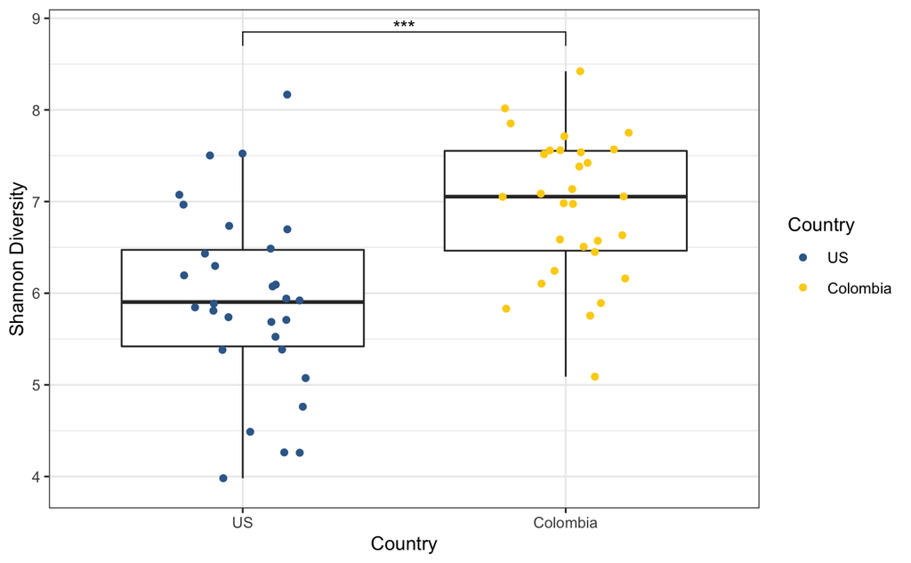

```r
shplot <- ggplot(sh, aes(Country, `Shannon Diversity`)) + geom_boxplot(outlier.shape = NA) + geom_dotplot(binaxis='y', stackdir='center', dotsize = 0) +
  theme_bw() +
  geom_point(aes(colour = Country), position = position_jitterdodge(), size = 1.5) +
  scale_color_manual(values = c("US" = "#396998", "Colombia" = "#FCD116")) +
  scale_x_discrete(limits=rev) +
  stat_pvalue_manual(stat.test.sh, y.position = 8.85, label = "p.adj.label")
#+ geom_bracket()
shplot
```

Now, import the Pielou evenness data

```r
pe <- read_tsv("evenness.txt")
stat.test.pe <- tibble::tribble(
  ~group1,  ~group2,     ~p.adj,   ~p.adj.label,
    "US",  "Colombia",  0.00039,  "***"
  )
```

Create the boxplot

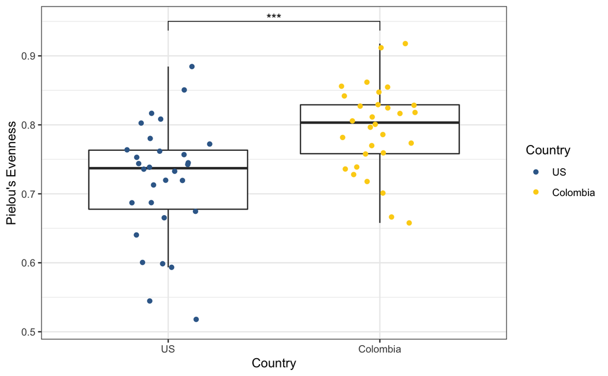

```r
peplot <- ggplot(pe, aes(Country, `Pielou's Evenness`)) + geom_boxplot(outlier.shape = NA) + geom_dotplot(binaxis='y', stackdir='center', dotsize = 0) +
  theme_bw() +
  geom_point(aes(colour = Country), position = position_jitterdodge(), size = 1.5) +
  scale_color_manual(values = c("US" = "#396998", "Colombia" = "#FCD116")) +
  scale_x_discrete(limits=rev) +
  stat_pvalue_manual(stat.test.pe, y.position = .95, label = "p.adj.label")
#+ geom_bracket()
peplot
```

Import the Faith’s phylogenetic diversity data

```r
fpd <- read_tsv("faithpd.txt")
stat.test.fpd <- tibble::tribble(
  ~group1,  ~group2,     ~p.adj,   ~p.adj.label,
    "US",  "Colombia",  0.00023,  "***"
  )
```

Create the boxplot

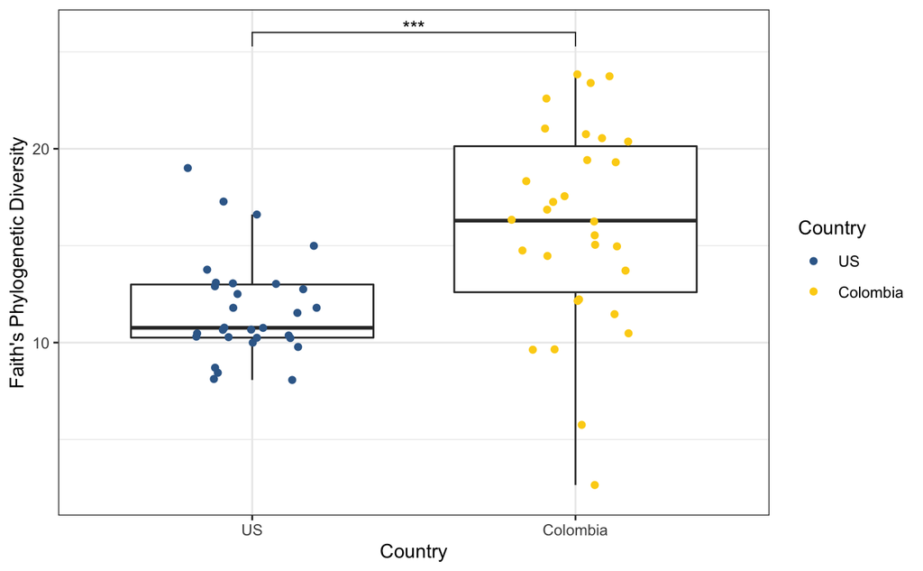

```r
fpdplot <- ggplot(fpd, aes(Country, `Faith's Phylogenetic Diversity`)) + geom_boxplot(outlier.shape = NA) + geom_dotplot(binaxis='y', stackdir='center', dotsize = 0) +
  theme_bw() +
  geom_point(aes(colour = Country), position = position_jitterdodge(), size = 1.5) +
  scale_color_manual(values = c("US" = "#396998", "Colombia" = "#FCD116")) +
  scale_x_discrete(limits=rev) +
  stat_pvalue_manual(stat.test.pe, y.position = 26, label = "p.adj.label")
#+ geom_bracket()
fpdplot
```

Combine all three boxplots. Label with A-C. Export as a .tiff file.

```r
ggarrange(fpdplot, shplot, peplot,
          common.legend = TRUE,
          legend = "right",
          labels = c("A", "B", "C"),
          ncol = 3, nrow = 1)
boxplots <- {{fpdplot + shplot + peplot}} +
  plot_layout(guides = "collect") + plot_annotation(tag_levels = list(c('A', 'B', 'C')))                     #optional labeling of individual plots
```

|  | t | l | b | r |
| --- | --- | --- | --- | --- |
| 1: | 1 | 1 | 1 | 1 |
| 2: | 1 | 2 | 1 | 2 |
| 3: | 1 | 3 | 1 | 3 |

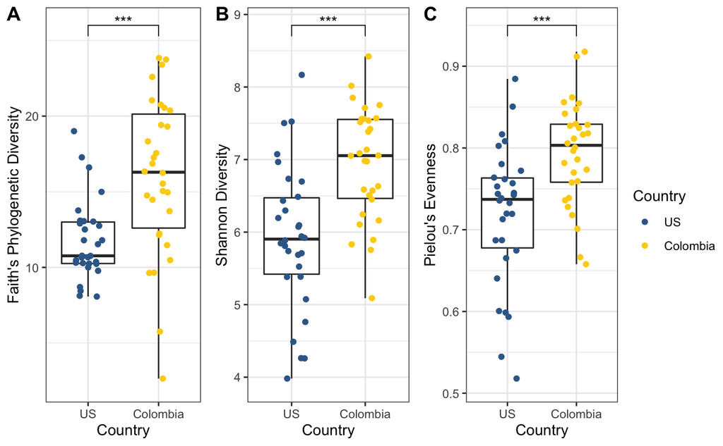

```r
ggsave("boxplots.tiff")
```